# Modelagem Linear: predição de geração de energia em usina de ciclo combinado.

Thales Henrique Barros Cardoso

2022-09-24

## Introdução

Para esse trabalho final, trago um conjunto de dados, modificado para essa atividade, sobre geração de energia em uma usina de ciclo combinado que foi utilizado em uma competição da página [Machine Hack](https://machinehack.com/hackathons/power_plant_energy_output_prediction_weekend_hackathon_13/overview).

O conjunto de dados foi coletado de uma Usina de Ciclo Combinado ao longo de 6 anos (2006-2011) quando a usina foi configurada para funcionar com carga total. Os recursos consistem em variáveis ambientais médias horárias Temperatura (T), Pressão Ambiente (AP), Umidade Relativa (RH) e Vácuo de Exaustão (V) para prever a saída horária líquida de energia elétrica (PE) da planta.

Uma usina de ciclo combinado (CCPP) é composta por turbinas a gás (GT), turbinas a vapor (ST) e geradores de vapor de recuperação de calor.

Em um CCPP, a eletricidade é gerada por turbinas a gás e a vapor, que são combinadas em um ciclo, e são transferidas de uma turbina para outra. Enquanto o Vácuo é coletado e tem efeito sobre a Turbina a Vapor, as outras três variáveis ambientais afetam o desempenho do GT.

## Gráficos e tabelas

#### Dados

```r
dados <- readr::read_rds("data/dados.rds")

dados |> head(5)
```

```
## # A tibble: 5 x 5
##      AT     V    AP    RH    PE
##   <dbl> <dbl> <dbl> <dbl> <dbl>
## 1 17.0   53.2 1014.  82.8  472.
## 2  9.6   41.0 1021.  69.0  494.
## 3  6.11  38.7 1018.  79.2  496.
## 4 12.3   43.2 1009.  78.2  480.
## 5 27.7   59.1 1017.  61.2  445.
```

Importante avaliar como o R interpretou as variáveis do conjunto de dados. Temos que todas elas são do tipo numérica `<dbl>`, sendo assim não será necessário modificar nenhuma delas.

```r
dados |> is.na() |> colSums()
```

```
## AT  V AP RH PE
##  0  0  0  0  0
```

Pode-se ver que não há valores `NA` no conjunto de dados.

#### Gráficos

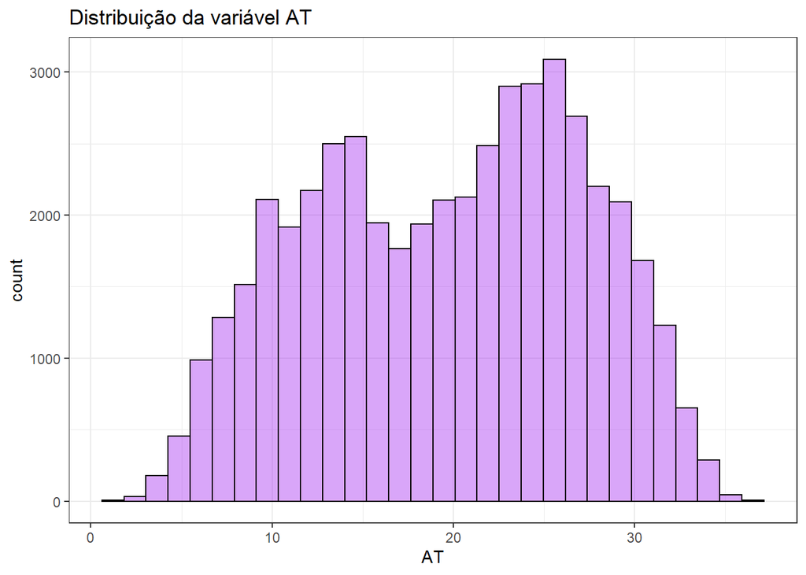

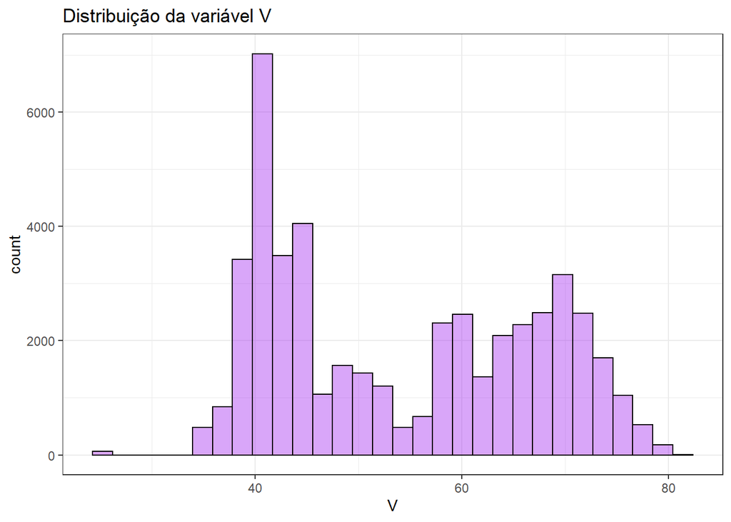

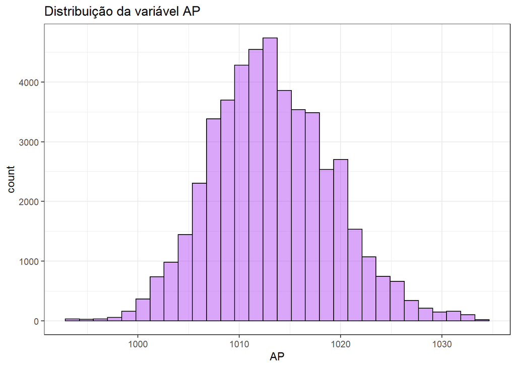

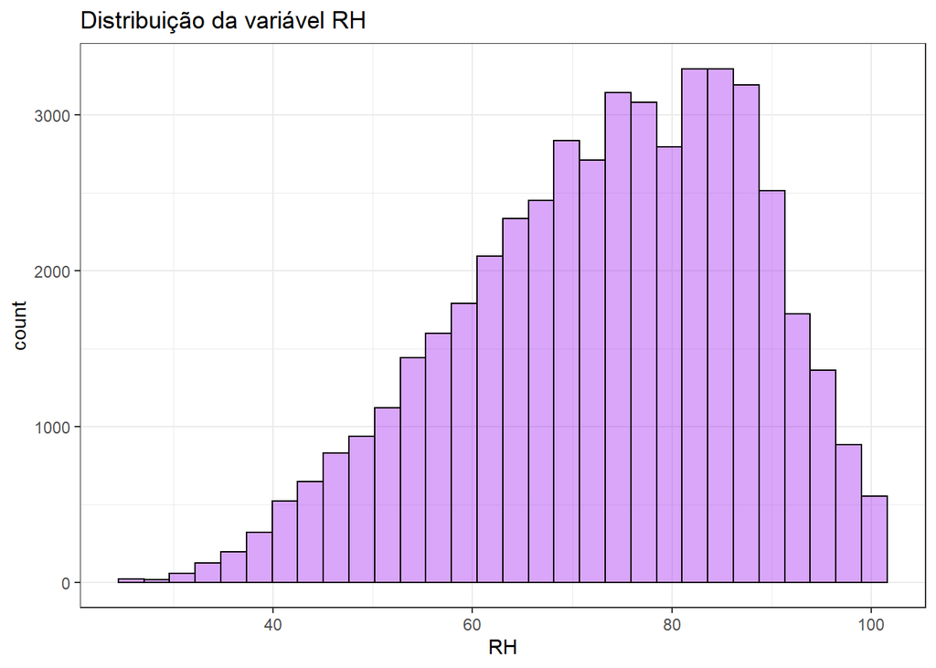

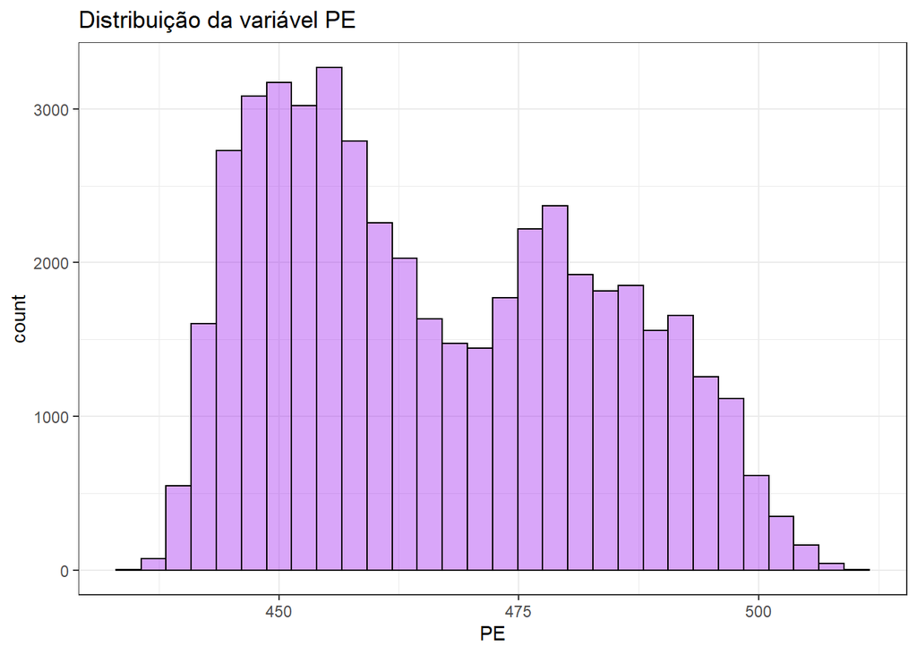

```r
histograma <- function(var) {

  dados |>
    ggplot2::ggplot() +
    ggplot2::aes(x = .data[[var]]) +
    ggplot2::geom_histogram(
      alpha = 0.4,
      color = "black",
      fill = "purple"
    ) +
    ggplot2::labs(
      title = glue::glue("Distribuição da variável {var}")
    ) +
    ggplot2::theme_bw()

}

vars <- colnames(dados)

purrr::map(vars, histograma)
```

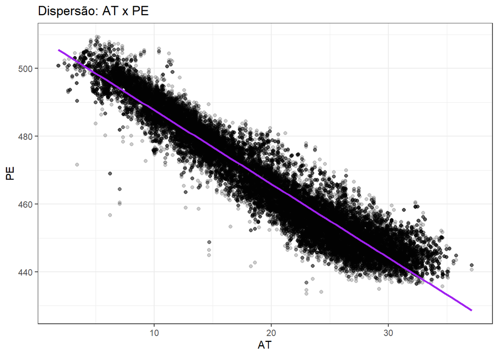

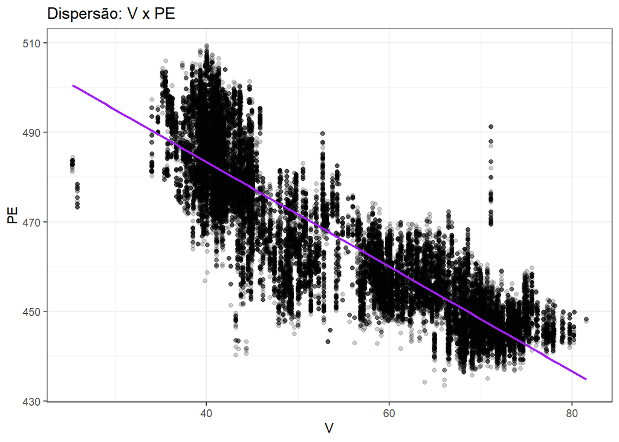

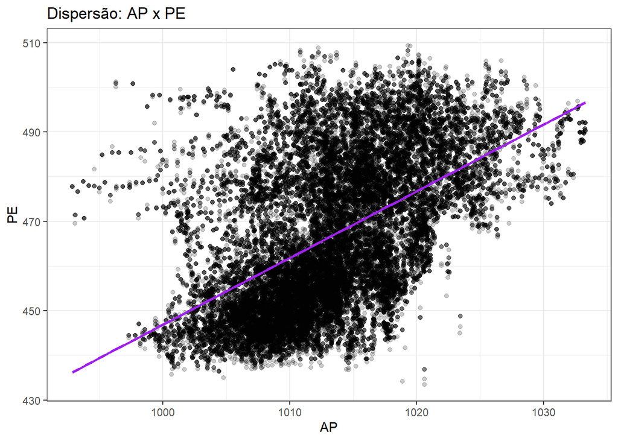

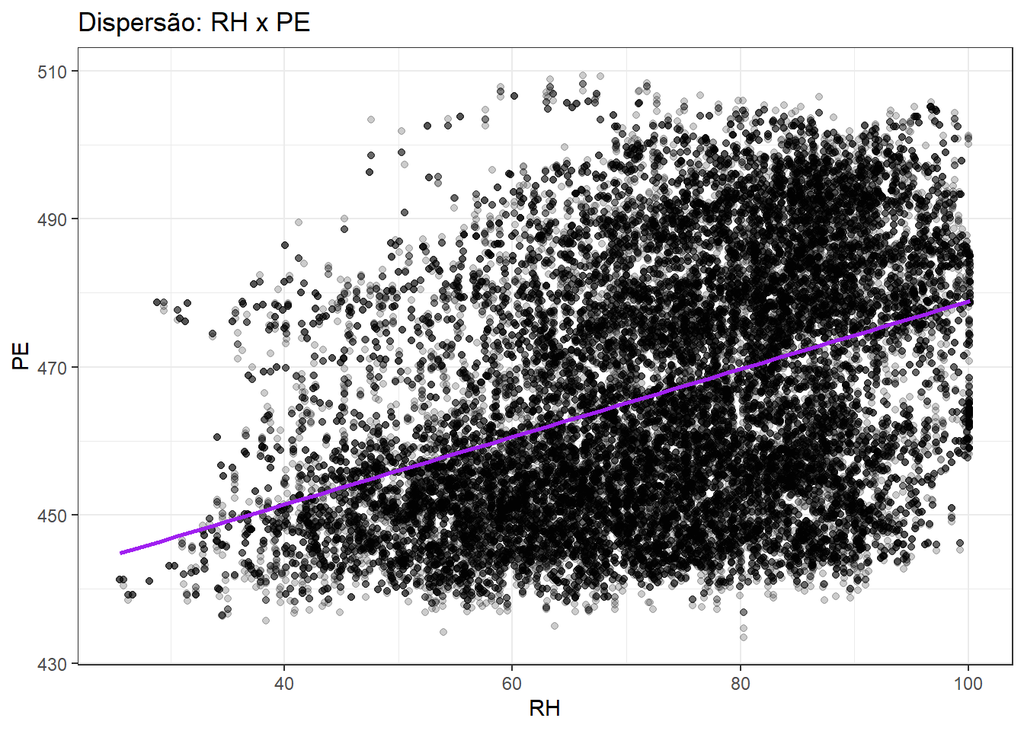

```r
scatter <- function(var) {

  dados |>
    ggplot2::ggplot() +
    ggplot2::aes(x = .data[[var]], y = PE) +
    ggplot2::geom_jitter(alpha = 0.2) +
    ggplot2::geom_smooth(color = "purple", method = "lm", se = FALSE) +
    ggplot2::labs(
      title = glue::glue("Dispersão: {var} x PE")
    ) +
    ggplot2::theme_bw()

}

vars <- c("AT", "V", "AP", "RH")

purrr::map(vars, scatter)
```

Os scatterplots acima nos mostram o elacionamento entre as variáveis preditoras com a variável resposta do nosso problema. As variáveis AT e V, possuem um comportamento linear bastante forte com a variável resposta. Já as variáveis AP e RH estão um pouco mais dispersas na área de plotagem, indicando uma relação mais fraca com a variável resposta.

#### Correlação das variáveis

```r
correlacao <- cor(dados)

correlacao
```

```
##            AT          V          AP          RH         PE
## AT  1.0000000  0.8441067 -0.50754934 -0.54253465 -0.9566698
## V   0.8441067  1.0000000 -0.41350216 -0.31218728 -0.8766855
## AP -0.5075493 -0.4135022  1.00000000  0.09957432  0.5234254
## RH -0.5425347 -0.3121873  0.09957432  1.00000000  0.3938820
## PE -0.9566698 -0.8766855  0.52342540  0.39388203  1.0000000
```

Os valores das correlações de Pearson entre as variáveis nos indica que há uma relação linear forte entre as variáveis AT e V com a variável resposta, o que foi visto nos scatterplots anteriormente. Já as variáveis AP e RH possuem uma relação fraca/média com a variável PE. Todas elas são bastante interessantes para a construção do modelo de regressão. Porém algumas das variáveis preditoras possuem uma correlação de Pearson com valor bastante alto (AT e V) entre elas, o que pode indicar uma colinearidade que atrapalhe os resultados obtidos pelo modelo, pois pode ser que estejam nos dizendo a mesma coisa sobre os dados. Para verificar isso de forma mais acertiva, iremos criar um modelo com todas as variáveis do conjunto de dados e verificar através da função `vif` (variance inflation factor), quais as que possuem maior colinearidade com as outras variáveis do modelo.

#### Variance inflation factor (vif)

```r
modelo_0_0 <- lm(PE ~ ., dados)

performance::check_collinearity(modelo_0_0)
```

[output not shown]

```r
modelo_0_1 <- lm(PE ~ AT + AP + RH, dados)

performance::check_collinearity(modelo_0_1)
```

```
## # Check for Multicollinearity
##
## Low Correlation
##
##  Term  VIF   VIF 95% CI Increased SE Tolerance Tolerance 95% CI
##    AT 2.01 [1.98, 2.04]         1.42      0.50     [0.49, 0.50]
##    AP 1.43 [1.42, 1.45]         1.20      0.70     [0.69, 0.71]
##    RH 1.51 [1.49, 1.52]         1.23      0.66     [0.66, 0.67]
```

```r
modelo_0_2 <- lm(PE ~ V + AP + RH, dados)

performance::check_collinearity(modelo_0_2)
```

```
## # Check for Multicollinearity
##
## Low Correlation
##
##  Term  VIF   VIF 95% CI Increased SE Tolerance Tolerance 95% CI
##     V 1.32 [1.31, 1.34]         1.15      0.75     [0.75, 0.76]
##    AP 1.21 [1.20, 1.22]         1.10      0.83     [0.82, 0.84]
##    RH 1.11 [1.10, 1.12]         1.05      0.90     [0.89, 0.91]
```

Com isso, podemos ver que os valores conseguidos através da função `vif`, para AT e V, são mais altos do que as duas outras variáveis e que também o valor da correlação de Pearson dessas duas variáveis é bastante significativo. Assim podemos considerar que há colinearidade entre essas variáveis e portanto não faz sentido manter as duas na construção do modelo de regressão, porém posteriormente analisaremos as métricas necessárias para decidir se o modelo é melhor ou pior com ou sem as duas variáveis (AT e V).

Quando fazemos um teste e retiramos a variável V ou a variável AT do modelo, temos que nenhuma das variáveis possue um valor `vif` maior que cinco. Sendo um bom indício de que as variáveis com maior colinearidade são mesmo as variáveis AT e V.

## Modelagem

O modelo criado para verificar a colinearidade das variáveis, foi criado com todas as variáveis do conjunto de dados. Sendo o a partir dele que conduziremos a análise do modelo de regressão. Também é importante dizer que a partir desse momento iremos dividir o conjunto de dados em dois, uma para treinar o modelo e outro para testar posteriormete, apresentando uma parte do conjunto de dados como se fossem dados novos, para assim termos uma real dimensão do quão bom será o modelo.

```r
tamanho_amostra <- floor(0.8 * nrow(dados))

set.seed(100)

treino_index <- sample(nrow(dados), size = tamanho_amostra)

dados_treino <- dados[treino_index,]

dados_teste <- dados[-treino_index,]
```

```r
modelo_linear <- parsnip::linear_reg() |>
  parsnip::set_engine("lm") |>
  parsnip::set_mode("regression")

metricas <- yardstick::metric_set(
  yardstick::rmse,
  yardstick::rsq,
  yardstick::mae
)
```

#### Avaliando multicolinearidade e a significância dos coeficientes do modelo

```r
modelo_1 <- modelo_linear |>
  parsnip::fit(PE ~ ., dados_treino) |>
  parsnip::extract_fit_engine()

summary(modelo_1)
```

```
##
## Call:
## stats::lm(formula = PE ~ ., data = data)
##
## Residuals:
##     Min      1Q  Median      3Q     Max
## -37.634  -2.758  -0.203   2.630  18.246
##
## Coefficients:
##               Estimate Std. Error t value Pr(>|t|)
## (Intercept) 465.825872   4.265579  109.21   <2e-16 ***
## AT           -1.984849   0.006684 -296.95   <2e-16 ***
## V            -0.230203   0.003182  -72.35   <2e-16 ***
## AP            0.063062   0.004138   15.24   <2e-16 ***
## RH           -0.157906   0.001825  -86.54   <2e-16 ***
## ---
## Signif. codes:  0 '***' 0.001 '**' 0.01 '*' 0.05 '.' 0.1 ' ' 1
##
## Residual standard error: 3.985 on 38267 degrees of freedom
## Multiple R-squared:  0.9447, Adjusted R-squared:  0.9447
## F-statistic: 1.634e+05 on 4 and 38267 DF,  p-value: < 2.2e-16
```

Um ponto importante na construção desse modelo com todas as variáveis preditoras é que ele possui um valor bem alto na métrica do R-quadrado, como podemos ver acima. Sabemos que quanto mais variáveis o modelo tem, maior será a métrica R-quadrado, assim vale a pena avaliar se modelos mais simples, com menos variáveis, manterão a acurácia, errando aproximadamente a mesma coisa. Dessa forma ao construir modelos sem uma das varáveis que são colineares, devemos observar se teremos uma perda significativa na métrica do R-quadrado, ou em qualquer outra que esteja utilizando para o problema.

Vale ressaltar que o modelo criado incialmente nos indica que as variáveis são significativas para predizer a variável resposta do problema. Isso pode ser observado pelo valor-p extremamente baixo, o que nos mostra uma baixíssima probabilidade de os coeficiente das variáveis serem iguais a zero, o que anularia a utilização do coeficiente.

```r
modelo_2 <- modelo_linear |>
  parsnip::fit(PE ~ AT + AP + RH, dados_treino) |>
  parsnip::extract_fit_engine()

summary(modelo_2)
```

```
##
## Call:
## stats::lm(formula = PE ~ AT + AP + RH, data = data)
##
## Residuals:
##     Min      1Q  Median      3Q     Max
## -39.031  -2.913  -0.064   2.755  19.378
##
## Coefficients:
##               Estimate Std. Error t value Pr(>|t|)
## (Intercept) 501.479699   4.517482  111.01  < 2e-16 ***
## AT           -2.378925   0.004131 -575.86  < 2e-16 ***
## AP            0.026449   0.004379    6.04 1.55e-09 ***
## RH           -0.203088   0.001828 -111.10  < 2e-16 ***
## ---
## Signif. codes:  0 '***' 0.001 '**' 0.01 '*' 0.05 '.' 0.1 ' ' 1
##
## Residual standard error: 4.249 on 38268 degrees of freedom
## Multiple R-squared:  0.9371, Adjusted R-squared:  0.9371
## F-statistic: 1.901e+05 on 3 and 38268 DF,  p-value: < 2.2e-16
```

Não há uma diferença muito significativa na métrica do R-quadrado quando retiramos da criação do modelo linear a variável V. Uma indicação forte de que tanto a variável AT e a variável V representem a mesma informação, ou quase, para o modelo. Nesse segundo modelo também é possível observar que os coeficientes relacionados as variáveis são significativos para o modelo, indicando através do valor-p que as probabilidades desses valores serem igual a zero é extremamente baixa.

```r
modelo_3 <- modelo_linear |>
  parsnip::fit(PE ~ V + AP + RH, dados_treino) |>
  parsnip::extract_fit_engine()

summary(modelo_3)
```

```
##
## Call:
## stats::lm(formula = PE ~ V + AP + RH, data = data)
##
## Residuals:
##     Min      1Q  Median      3Q     Max
## -39.226  -4.832  -0.307   4.259  36.047
##
## Coefficients:
##               Estimate Std. Error  t value Pr(>|t|)
## (Intercept) -68.415817   7.030316   -9.732   <2e-16 ***
## V            -1.000073   0.003352 -298.307   <2e-16 ***
## AP            0.569877   0.006852   83.165   <2e-16 ***
## RH            0.162654   0.002674   60.828   <2e-16 ***
## ---
## Signif. codes:  0 '***' 0.001 '**' 0.01 '*' 0.05 '.' 0.1 ' ' 1
##
## Residual standard error: 7.243 on 38268 degrees of freedom
## Multiple R-squared:  0.8172, Adjusted R-squared:  0.8172
## F-statistic: 5.703e+04 on 3 and 38268 DF,  p-value: < 2.2e-16
```

Entretanto, quando retiramos a variável AT do modelo, há uma redução significativa da métrica R-quadrado, de certa forma, indicando que a variável AT tem uma importância maior para a predição dos valores da variável resposta do que a variável V.

Logo, a retirada da variável V não interfere de forma expressiva no resultado final do modelo criado, podendo assim, ser retirada sem prejuízos deixando, inclusive, o modelo mais simplificado. Pórem, antes de decretar que o modelo com menos variáveis é melhor que o com todas variáveis, iremos fazer um diagnóstico dos modelos, avaliando se há algum ponto de alavanca, ou se os resíduos estão orbitando em volta do zero, se há ou não heterocedasteicidade.

#### Avaliação dos modelos

Como aventamos a hipótese que a variável V pode ser excluída do modelo que queremos criar, vamos fazer a avaliação tanto do modelo com todas as variáveis quanto com o sem a variável V.

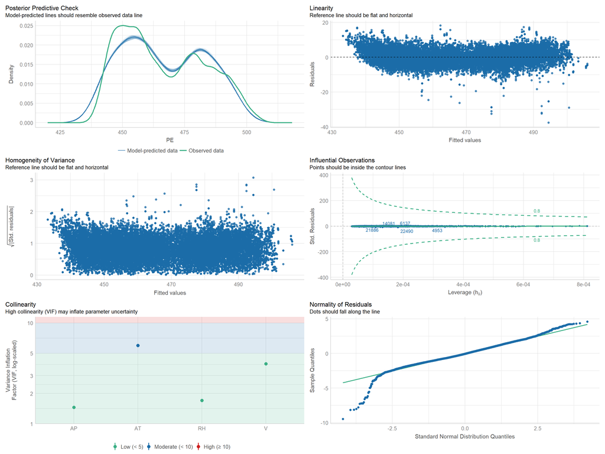

```r
performance::check_model(modelo_1)
```

No primeiro modelo treinado, que tem todas as variáveis preditoras, é possível ver que a há homogeineidade da variância dos resíduos, e portanto não há no modelo o fenômeno da heterocedasteicidade. Também é possível observar pelo gráfico de linearidade que a relação obtida pelo modelo é linear, não precisando realizar transformações extras nas variáveis do modelo. No gráfico de observações influentes, não é observado nenhum ponto que influencia o modelo de forma que possa alterar o resultado dos coeficientes do modelo linear. Na representação que mostra a normalidade dos resídios, também temos indício de que o modelo está condizente com o que deveria ser. E no gráfico de colinearidade observamos novamente o que já foi discutido anteriormente neste mesmo relatório.

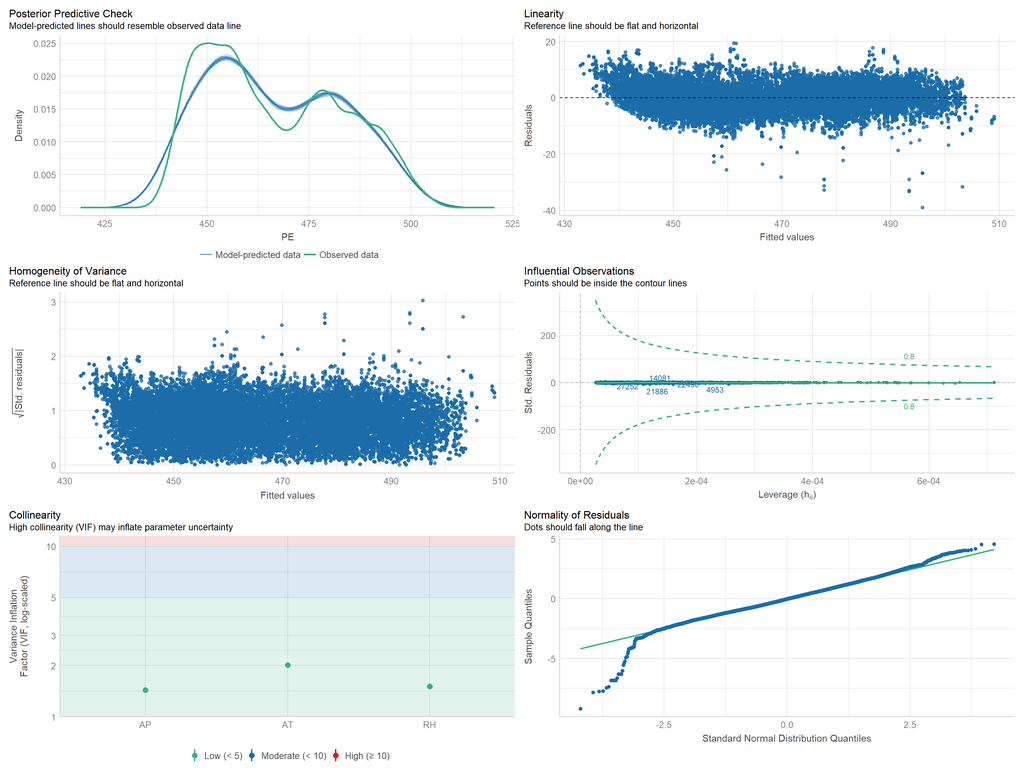

```r
performance::check_model(modelo_2)
```

Esse segundo modelo sem a variável V possui as mesmas características do modelo anterior. A única diferença é que no gráfico de colinearidade, todas as três variáveis preditoras disponíveis não tem colinearidade entre si.

#### Testando o modelo com valores novos

inicialmente vamos utilizar os dados separados para teste, prever o resultado e comparar com o resultado original.

```r
pred_1 <- predict(modelo_1, dados_teste)

pred_2 <- predict(modelo_2, dados_teste)

dados_com_previsão <- dados_teste |>
  dplyr::mutate(
    PE_pred_1 = pred_1,
    PE_pred_2 = pred_2
  )
```

Valores das métricas com o modelo que incorpora todas as variáveis preditoras.

```r
dados_com_previsão |>
  metricas(truth = PE, estimate = PE_pred_1)
```

```
## # A tibble: 3 x 3
##   .metric .estimator .estimate
##   <chr>   <chr>          <dbl>
## 1 rmse    standard       3.93
## 2 rsq     standard       0.946
## 3 mae     standard       3.11
```

Valores das métricas com o modelo que exclui a variável V, pois como já demonstrado acima, possui uma colinearidade muito forte com a variável AT. Reforçando que a exclusão da variável V é feita a partir da percepção de que ela menos importante para a predição da variável resposta.

```r
dados_com_previsão |>
  metricas(truth = PE, estimate = PE_pred_2)
```

```
## # A tibble: 3 x 3
##   .metric .estimator .estimate
##   <chr>   <chr>          <dbl>
## 1 rmse    standard       4.19
## 2 rsq     standard       0.939
## 3 mae     standard       3.31
```

Como podemos observar, as métricas de avaliação dos valores preditos, quando comparados aos valores verdadeiros, nos mostra que os modelos não estão sobreajustados. E um ponto bastante interessante a se perceber, é que o modelo com todas as variáveis preditoras possui métricas melhores, porém, que na minha opinião, não justificam utilizar um modelo mais complexo.

## Conclusão

Ao longo de todo o processo de análise das variáveis e construções dos modelos, se pode verificar que existe uma relação de linearidade entre as variáveis preditoras e a variável resposta. Isso pode ser constatado através da correlação de Pearson, que mede a força e o sentido da relação linear entre duas variáveis, e também através da visualização pelos gráficos de pontos entre uma variável preditora e a resposta.

Tudo isso nos leva a análise da significância dos coeficentes relacionados a cada um dos preditores, nos mostrando um valor-p extremamente baixo, indicando uma baixa probabilidade de que esses coefiencentes sejam igual a zero, podendo, nesse caso, rejeitar essa hipótese. Levando isso em consideração, se concluiu que todas as variáveis possuem significância para o modelo, porém devido a duas delas terem um fator de colinearidade muito forte, se decidiu por utilizar um modelo de regressão linear multípla sem a variável V, deixando o modelo mais simples.

E por último, as métricas calculadas com valores novos, da parte do conjunto de dados destinada a teste, nos mostra que ambos os modelos, tanto o primeiro que possui todas as variáveis preditoras, quanto o segundo que não tem a presença da variável V, não estão sobreajustados, portanto os modelos performam bem tanto com os dados de treino, quanto com os dados de teste.